# Introduction to Game Theory

with Connor T. Wiegand

## Intro

### What are examples of games?

- Ticket to Ride
- League
- Football
- Baldur’s Gate
- Duopoly competition
- Job Market

### Game theory Games

- Typically smaller-scale, isloated scenarios
  - Analyze a piece of a bigger game
  - In a vacuum (remember: modeling discipline)
- Prisoner’s Dilema
- Matching Pennies
- Chicken
- Beer/quiche
- RPS
- How much college? (job market signaling)
- BoS

### Who Cares?

- Amazon
- Verizon
- Coke/Pepsi
- Valve
- Everyday Uses:
  - How should you fight family over the holidays?
  - How should you approach returning an item to a store?
  - When should you email your professor?

## What’s in a Game?

### From last time…

- There are three things that are essential to specifying a game:
1. Players
2. Strategies
3. Payoffs

### Players

- Agents, users, etc.
- To be a proper game, there should be at least 2 players
- Ex Sukhjit is taking a penalty kick in soccer. There is a 50% chance the goalie defends left, and 20% chance they defend the middle, and a 30% chance they defend right.
- This is something we might think of as a “game”, but is really just a decision with some exogeneity<sup>1</sup> from the environment
- Having two or more *real* players is sometimes known as “strategic interaction”
[^1]: exogenous = ‘falls from the sky’

### Strategies

- AKA
  - Moves
  - Actions
- What choices the player has
- For now, the above terms can be treated as identical
- Later, when we get to sequential games, we will start using these terms with a little more care
  - Namely, a **strategy** is an an information-contingent plan of action
  - An action is a *component* of a strategy
- Typically finite, can be infinite
  - Ultimatum game, 2/3 avg, price-setting

### Payoffs

- Crucial to economics
- The payoff/utility<sup>1</sup> obtained from a specific outcome in a game
  - (outcome = result of each player playing a pre-determined **strategy**)
- Can be specified via a function
  - Ex. $\pi(P,Q) = (100 + q_{1} + q_2) - 5q_1$
- Or a list
  - Ex. Outcomes $(A, B, C, D)$ correspond to payoffs $(20, 40, 60, 80)$
  - Ex. $u(s_1, s_2)=$ `<value>` for each strategy $s_i$ that player $i$ could play
- Basically: a map from outcomes to numbers
[^2]: We may use either of $u(\cdot)$ (“utility”) or $\pi(\cdot)$ (“payoff”)

## Assumptions in Game Theory

### Assumptions

- Suppose that you and I represent the players in a game
- One mild assumption we would like to impose is that you and I are on the same page regarding the details of the game
  - e.g., the players, strategies, and outcomes
- We refer to these details as the rules of the game
- But how do we formalize “on the same page”?

### The Rules of the Game

1. I know the rules of the game
- I know that you know the rules of the game
- I know that you know that I know the rules of the game
- I know that you know that I know that you know the rules of the game
- …
2. You know the rules of the game
- You know that I know the rules of the game
- You know that I know that you know the rules of the game
- You know that I know that you know that I know the rules of the game
- …

### Common Knowledge of RotG

Let $\Gamma$ be a game with players $P_1,\dots,P_n$

Assumption 1: Common Knowledge of the Rules of the Game

- *Every statement of the form “player $i$ knows that player $j$ knows that … player $k$ knows the rules of the game” is true*

[video not shown]

- [Blue Eyed Islander Problem – backup](https://www.youtube.com/watch?v=98TQv5IAtY8)

### Assumptions, cont.

1. Common Knowledge of the Rules of the Game
2. Common Knowledge of **Rationality**
   1. I am rational
      - I know that you are rational
      - I know that you know that I am rational
      - …
   2. You are rational
      - You know that I am rational
      - You know that I know that you are rational
      - …

… but what is rationality?

### Rationality

What is it?

- Players maximize their expected payoffs

Technically speaking, rational agents are those who exhibit preferences which satisfy both of:

1. Completeness
2. Transitivity

### Wait, what?

Recall:

- In microeconomics, agents are said to have *preferences* over goods (or *bundles* of goods)
- We represent these preference relations with the $\succsim$ symbol, as follows
- For (bundles of) goods $x$ and $y$, consider Taylor’s preferences:
  - $x\succsim y$ reads *“Taylor weakly prefers $x$ to $y$”*
    - or *“Taylor wants $x$ as least as much as $y$”*
  - $y\succsim x$ reads *“Taylor weakly prefers $y$ to $x$”*
- This allows us to define two more notions:
  - When $x\succsim y$ and $y\succsim x$, we say
    - $x\sim y$: *“Taylor is indifferent between $x$ and $y$”*
  - When $x\succsim y$ but $y\not\succsim x$, we say
    - $x\succ y$: *“Taylor strictly prefers $x$ to $y$”*

### Rational Preferences

1. Completeness:
   - Def Given $x,y\in X$, an agent’s preferences are **complete** provided at least one of the following is true:
     - $x\succsim y$
     - $y \succsim x$
   - Ex.: Jump to appendix
2. Transitivity:
   - Def Given $x, y, z\in X$, suppose that $x\succsim y$ and $y\succsim z$. Under these conditions, an agent’s preferences are **transitive** provided that $x\succsim z$
   - Ex.  
     Jake roots for the Lions when they play the Bengals, and the Bengals when they play the Bears. **But**, Jake roots for the Bears when they play the Lions

### Assumptions

…so…?

- We assume agents’ preferences follow the classical assumptions of microeconomics…
  - (Players maximize their expected payoffs)
- Given this, our two assumptions moving forward are
  1. Common Knowledge of the Rules of the Game
  2. Common Knowledge of Rationality
- and that’s it!

## Review

### Symbol Cheat-Sheets

*Some selected tables of symbols which may be useful*

- Greek
- Set Theory
- Logic

### Some Math Resources

- As-needed basis:
  - [Paul’s online math notes](https://tutorial.math.lamar.edu/Classes/Alg/Alg.aspx) is great
    - I have attached the link to the algebra section, but make sure to brief yourself with whatever you need (graphing, etc.).
- Overkill, but will be helpful to skim through before next class:
  - [Set theory video 1](https://www.youtube.com/watch?v=tyDKR4FG3Yw)
  - [Set theory video 2](https://www.youtube.com/watch?v=5ZhNmKb-dqk)
- Please reach out if you need further (specific) resources

## Appendix

### Incomplete Preferences

Via `economics.stackexchange`:

> Let $X$ be the number of possible baskets of goods that one can buy from a Walmart Superstore. Even if there were only 1,000 distinct items and we could only buy at most one of each item, that’d be $2^{1000}$ possible baskets. (Note that $X \gg 2^{1000}>10^{300}\gg10^{100}>$ “any estimate of the number of particles in the universe”.)

> Even as a normative matter, it is debatable whether a perfectly rational being “should” have a complete preference ordering over these $X$ baskets.

> But as a positive matter, many (if not all) human beings will not have a complete preference ordering over these $X$ baskets.

Go back

### Select Greek

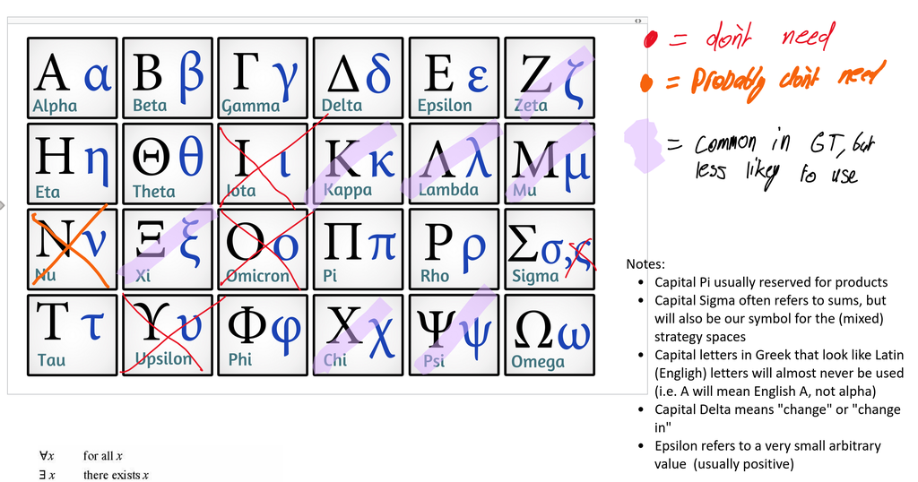

Go back

### Some Set Theory Symbols

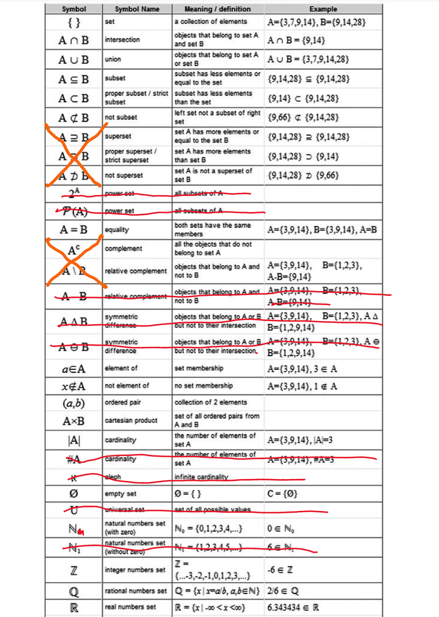

Go back

### Some Logical Symbols

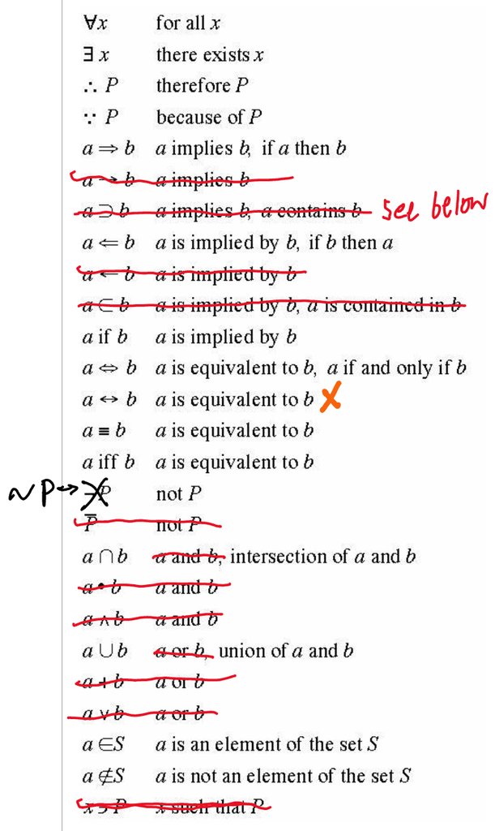

Go back

### Extra

To introduce these concepts, we began discussing strategy spaces, strategy profiles, and the set of strategy profiles, but this will be covered formally at a later date (e.g. next week)